# Part I - Loans Data Exploration

## Preliminary Wrangling

This data set contains 113,937 loans with 81 variables on each loan, including loan amount, borrower rate (or interest rate), current loan status, borrower income, and many others.

```python
# import all packages and set plots to be embedded inline
import numpy as np
import pandas as pd
import matplotlib.pyplot as plt
import seaborn as sb
import datetime

%matplotlib inline
```

```python
# loading the dataset
loans = pd.read_csv('prosperLoanData.csv')
```

```python
loans.sample(15)
```

|  | ListingKey | ListingNumber | ListingCreationDate | CreditGrade | Term | LoanStatus | ClosedDate | BorrowerAPR | BorrowerRate | LenderYield | ... | LP_ServiceFees | LP_CollectionFees | LP_GrossPrincipalLoss | LP_NetPrincipalLoss | LP_NonPrincipalRecoverypayments | PercentFunded | Recommendations | InvestmentFromFriendsCount | InvestmentFromFriendsAmount | Investors |
| --- | --- | --- | --- | --- | --- | --- | --- | --- | --- | --- | --- | --- | --- | --- | --- | --- | --- | --- | --- | --- | --- |
| 5243 | 40FB3418192169495D37F23 | 308450 | 2008-04-12 08:37:10.817000000 | C | 36 | Chargedoff | 2009-04-19 00:00:00 | 0.12562 | 0.1045 | 0.0945 | ... | -27.18 | 0.00 | 4147.39 | 4147.39 | 0.0 | 1.0 | 0 | 0 | 0.0 | 90 |
| 58882 | FEBC339045444343097E16E | 146879 | 2007-06-04 20:01:58.593000000 | B | 36 | Chargedoff | 2007-12-10 00:00:00 | 0.20735 | 0.2000 | 0.1900 | ... | -18.49 | 0.00 | 22033.68 | 22033.68 | 0.0 | 1.0 | 0 | 0 | 0.0 | 154 |
| 44817 | E50B3364462986726F7109A | 1523 | 2006-03-08 12:53:07.140000000 | HR | 36 | Completed | 2008-10-21 00:00:00 | 0.21857 | 0.2000 | 0.1825 | ... | -5.23 | -18.85 | 0.00 | 0.00 | 0.0 | 1.0 | 0 | 0 | 0.0 | 8 |
| 113423 | D6FC355639610135348CCCF | 628797 | 2012-08-25 10:37:15.630000000 | NaN | 36 | Completed | 2013-03-25 00:00:00 | 0.12528 | 0.0974 | 0.0874 | ... | -37.25 | 0.00 | 0.00 | 0.00 | 0.0 | 1.0 | 0 | 0 | 0.0 | 67 |
| 79669 | 56F13586020800315EF68F6 | 864298 | 2013-08-08 06:48:52.640000000 | NaN | 36 | Current | NaN | 0.19236 | 0.1559 | 0.1459 | ... | -19.05 | 0.00 | 0.00 | 0.00 | 0.0 | 1.0 | 0 | 0 | 0.0 | 17 |
| 48496 | AEE235838533783151F2606 | 838857 | 2013-07-14 16:01:34.673000000 | NaN | 60 | Current | NaN | 0.17522 | 0.1519 | 0.1419 | ... | -73.46 | 0.00 | 0.00 | 0.00 | 0.0 | 1.0 | 0 | 0 | 0.0 | 1 |
| 21183 | 48D13532279572242F6EE1A | 539319 | 2011-11-16 09:08:08.807000000 | NaN | 36 | Defaulted | 2013-02-04 00:00:00 | 0.35797 | 0.3177 | 0.3077 | ... | -27.96 | 0.00 | 3325.15 | 3325.15 | 0.0 | 1.0 | 0 | 0 | 0.0 | 15 |
| 29360 | 473534165997130484D9F9E | 295717 | 2008-03-19 14:25:00.020000000 | C | 36 | Completed | 2011-04-19 00:00:00 | 0.12562 | 0.1045 | 0.0945 | ... | -105.68 | 0.00 | 0.00 | 0.00 | 0.0 | 1.0 | 0 | 0 | 0.0 | 124 |
| 41224 | E1103599812214594B25BA2 | 1152621 | 2014-01-20 15:57:19.797000000 | NaN | 36 | Current | NaN | 0.11563 | 0.0879 | 0.0779 | ... | -2.27 | 0.00 | 0.00 | 0.00 | 0.0 | 1.0 | 0 | 0 | 0.0 | 1 |
| 60981 | 0C25360187703585836D18E | 1207974 | 2014-02-14 10:47:14.557000000 | NaN | 36 | Current | NaN | 0.20562 | 0.1685 | 0.1585 | ... | 0.00 | 0.00 | 0.00 | 0.00 | 0.0 | 1.0 | 0 | 0 | 0.0 | 1 |
| 77608 | 70703420879886160DB75E8 | 336675 | 2008-05-21 12:34:55.360000000 | HR | 36 | Chargedoff | 2008-12-05 00:00:00 | 0.33383 | 0.3099 | 0.2999 | ... | -2.47 | 0.00 | 2947.42 | 2947.42 | 0.0 | 1.0 | 3 | 2 | 200.0 | 68 |
| 12948 | 96F53372115100474E4F5C0 | 53723 | 2006-10-26 15:56:37.610000000 | B | 36 | Completed | 2008-05-01 00:00:00 | 0.13905 | 0.1320 | 0.1170 | ... | -26.42 | 0.00 | 0.00 | 0.00 | 0.0 | 1.0 | 0 | 0 | 0.0 | 102 |
| 27143 | A9303596674910386155D34 | 1069065 | 2013-12-04 12:05:14.067000000 | NaN | 36 | Current | NaN | 0.21342 | 0.1765 | 0.1665 | ... | -21.85 | 0.00 | 0.00 | 0.00 | 0.0 | 1.0 | 0 | 0 | 0.0 | 1 |
| 92894 | F9183589750833041B4C9B0 | 939966 | 2013-09-29 19:19:04.530000000 | NaN | 60 | Current | NaN | 0.21115 | 0.1870 | 0.1770 | ... | -50.68 | 0.00 | 0.00 | 0.00 | 0.0 | 1.0 | 0 | 0 | 0.0 | 1 |
| 101830 | D34A35733359545704E8D50 | 735429 | 2013-03-21 14:39:57.430000000 | NaN | 60 | Current | NaN | 0.20081 | 0.1769 | 0.1669 | ... | -124.89 | 0.00 | 0.00 | 0.00 | 0.0 | 1.0 | 0 | 0 | 0.0 | 243 |

15 rows × 81 columns

```python
loans.info()
print(loans.shape)
```

```
<class 'pandas.core.frame.DataFrame'>
RangeIndex: 113937 entries, 0 to 113936
Data columns (total 81 columns):
 #   Column                               Non-Null Count   Dtype
---  ------                               --------------   -----
 0   ListingKey                           113937 non-null  object
 1   ListingNumber                        113937 non-null  int64
 2   ListingCreationDate                  113937 non-null  object
 3   CreditGrade                          28953 non-null   object
 4   Term                                 113937 non-null  int64
 5   LoanStatus                           113937 non-null  object
 6   ClosedDate                           55089 non-null   object
 7   BorrowerAPR                          113912 non-null  float64
 8   BorrowerRate                         113937 non-null  float64
 9   LenderYield                          113937 non-null  float64
```

[output cut: 74 more lines]

The data dictionary provided(https://docs.google.com/spreadsheets/d/1gDyi_L4UvIrLTEC6Wri5nbaMmkGmLQBk-Yx3z0XDEtI/edit#gid=0) here gives us a description of each column.

There are some columns that have unique values and thus are not useful to our investigation. These variables are dropped.

```python
# droping specific columns
loans.drop(columns=["ListingKey","ListingNumber","GroupKey","LoanKey","LoanNumber","MemberKey","DateCreditPulled"],inplace= True )
```

```python
loans.describe()
```

|  | Term | BorrowerAPR | BorrowerRate | LenderYield | EstimatedEffectiveYield | EstimatedLoss | EstimatedReturn | ProsperRating (numeric) | ProsperScore | ListingCategory (numeric) | ... | LP_ServiceFees | LP_CollectionFees | LP_GrossPrincipalLoss | LP_NetPrincipalLoss | LP_NonPrincipalRecoverypayments | PercentFunded | Recommendations | InvestmentFromFriendsCount | InvestmentFromFriendsAmount | Investors |
| --- | --- | --- | --- | --- | --- | --- | --- | --- | --- | --- | --- | --- | --- | --- | --- | --- | --- | --- | --- | --- | --- |
| count | 113937.000000 | 113912.000000 | 113937.000000 | 113937.000000 | 84853.000000 | 84853.000000 | 84853.000000 | 84853.000000 | 84853.000000 | 113937.000000 | ... | 113937.000000 | 113937.000000 | 113937.000000 | 113937.000000 | 113937.000000 | 113937.000000 | 113937.000000 | 113937.000000 | 113937.000000 | 113937.000000 |
| mean | 40.830248 | 0.218828 | 0.192764 | 0.182701 | 0.168661 | 0.080306 | 0.096068 | 4.072243 | 5.950067 | 2.774209 | ... | -54.725641 | -14.242698 | 700.446342 | 681.420499 | 25.142686 | 0.998584 | 0.048027 | 0.023460 | 16.550751 | 80.475228 |
| std | 10.436212 | 0.080364 | 0.074818 | 0.074516 | 0.068467 | 0.046764 | 0.030403 | 1.673227 | 2.376501 | 3.996797 | ... | 60.675425 | 109.232758 | 2388.513831 | 2357.167068 | 275.657937 | 0.017919 | 0.332353 | 0.232412 | 294.545422 | 103.239020 |
| min | 12.000000 | 0.006530 | 0.000000 | -0.010000 | -0.182700 | 0.004900 | -0.182700 | 1.000000 | 1.000000 | 0.000000 | ... | -664.870000 | -9274.750000 | -94.200000 | -954.550000 | 0.000000 | 0.700000 | 0.000000 | 0.000000 | 0.000000 | 1.000000 |
| 25% | 36.000000 | 0.156290 | 0.134000 | 0.124200 | 0.115670 | 0.042400 | 0.074080 | 3.000000 | 4.000000 | 1.000000 | ... | -73.180000 | 0.000000 | 0.000000 | 0.000000 | 0.000000 | 1.000000 | 0.000000 | 0.000000 | 0.000000 | 2.000000 |
| 50% | 36.000000 | 0.209760 | 0.184000 | 0.173000 | 0.161500 | 0.072400 | 0.091700 | 4.000000 | 6.000000 | 1.000000 | ... | -34.440000 | 0.000000 | 0.000000 | 0.000000 | 0.000000 | 1.000000 | 0.000000 | 0.000000 | 0.000000 | 44.000000 |
| 75% | 36.000000 | 0.283810 | 0.250000 | 0.240000 | 0.224300 | 0.112000 | 0.116600 | 5.000000 | 8.000000 | 3.000000 | ... | -13.920000 | 0.000000 | 0.000000 | 0.000000 | 0.000000 | 1.000000 | 0.000000 | 0.000000 | 0.000000 | 115.000000 |
| max | 60.000000 | 0.512290 | 0.497500 | 0.492500 | 0.319900 | 0.366000 | 0.283700 | 7.000000 | 11.000000 | 20.000000 | ... | 32.060000 | 0.000000 | 25000.000000 | 25000.000000 | 21117.900000 | 1.012500 | 39.000000 | 33.000000 | 25000.000000 | 1189.000000 |

8 rows × 59 columns

### What is/are the main feature(s) of interest in your dataset?

> when we hear about loans we tend to think majorly borrowing and lending.The general objective of this project is to study the determinants that contribute to loan borrowing and payment. Some of the questions I want to answer using this dataset are:
> - What factors influences a loan’s outcome?
>   - Are there differences between loans depending on how large the original loan amount was?
>   - Is the prosper risk management efficient
>   - Does the prosper score and rate impact on borrowers rate

> The main features of interest will therefore be loanstatus, loan original amount and monthly loan payment. Any other variable that play a role in loan borrowing and lending will also be investigated

### What features in the dataset do you think will help support your investigation into your feature(s) of interest?

> The features that will help with the investigation are: loanstatus, borrowerAPR, borrowerRate, listing category, prosperrating, monthly income, occupation, term and employment status.

## Univariate Exploration

**Q1.Distributions of the main numeric variables.**

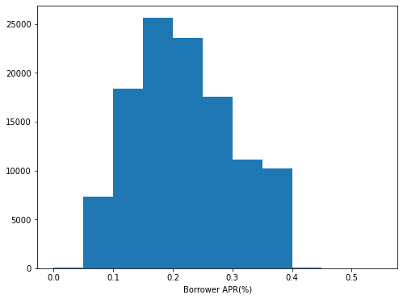

```python
# histogram of Borrower APR
plt.figure(figsize = [20, 5])
binsize = 0.05
bins = np.arange(0, loans['BorrowerAPR'].max()+binsize, binsize)
plt.figure(figsize=[8,6])
plt.hist(data= loans, x= 'BorrowerAPR', bins= bins);
plt.xlabel('Borrower APR(%)')
```

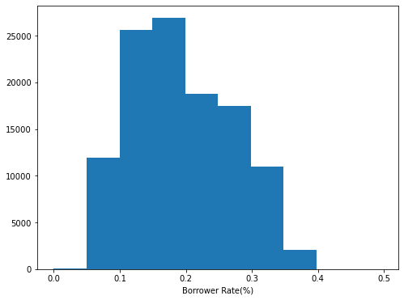

```python
plt.figure(figsize=[8,6])
plt.hist(data= loans, x= 'BorrowerRate')
plt.xlabel('Borrower Rate(%)')
plt.show()
```

The distribution is unimodal with a peak between 0.1% and 0.2%

**Q2.What is the range of monthly income for most borrowers?**

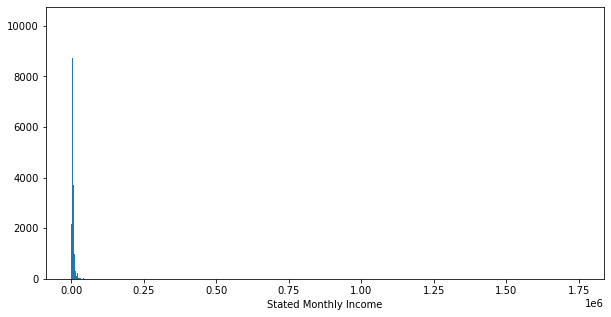

```python
x_bins = np.arange(0,loans.StatedMonthlyIncome.max()+500,500)
plt.figure(figsize=[10,5])
plt.hist(x=loans.StatedMonthlyIncome,bins = x_bins);
plt.xlabel("Stated Monthly Income");
```

The histogram plot of the original data is highly skewed to the right , this may be bacause the range of monthly income is high.A high range also implies presence of outliers.

```python
loans['StatedMonthlyIncome'].describe()
```

```
count    1.139370e+05
mean     5.608026e+03
std      7.478497e+03
min      0.000000e+00
25%      3.200333e+03
50%      4.666667e+03
75%      6.825000e+03
max      1.750003e+06
Name: StatedMonthlyIncome, dtype: float64
```

A summary of the StatedmonthlyIncome shows that the maximum value is 1750000, which is likely to be an error because the third quartile is only 6825. A minimum monthly income of 0 might be because the individuals are unemployed and doesnt have an income. We can make a plot with monthlyIncome of 12500 and below.

```python
salary= (loans['StatedMonthlyIncome'] <= 12500)
loans_1=loans.loc[salary,:]
```

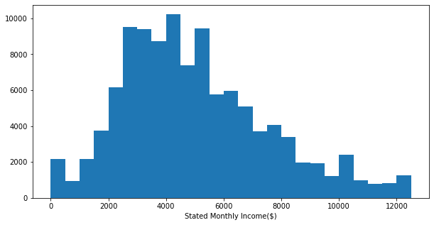

```python
# A plot with the monthly income of approximately 12500 and below
x_bins = np.arange(0,loans_1.StatedMonthlyIncome.max()+500,500)
plt.figure(figsize=[10,5])
plt.hist(x=loans_1.StatedMonthlyIncome,bins = x_bins);
plt.xlabel("Stated Monthly Income($)");
```

most of the monthly income for the borrowers in range 2k to 6k. The distribution is right skewed.

**Q3.What are some patterns in regard to the amount borrowed?**

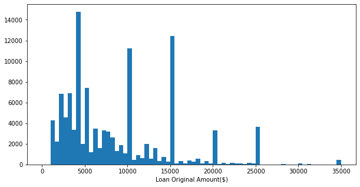

```python
bins = np.arange(0,loans.LoanOriginalAmount.max()+500,500)
plt.figure(figsize=[10,5])
plt.hist(x=loans.LoanOriginalAmount,bins=bins);
plt.xlabel("Loan Original Amount($)");
```

**Q4. What is the distribution of loan monthly payment?**

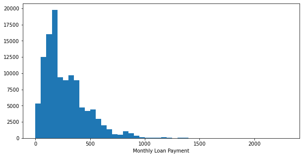

```python
bins = np.arange(0,loans.MonthlyLoanPayment.max()+50,50)
plt.figure(figsize=[10,5])
plt.hist(x=loans.MonthlyLoanPayment,bins=bins);
plt.xlabel("Monthly Loan Payment");
```

The distribution is highly skewed to the right. We can apply a log transformation to the MonthlyLoanPayment.A lot of borrowers pay little and few pay much.

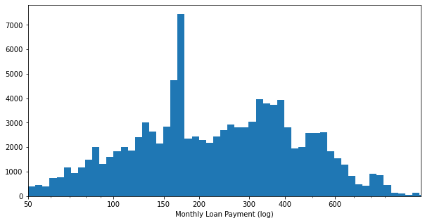

```python
bins = 10**np.arange(0,np.log10(loans.MonthlyLoanPayment.max())+0.025,0.025)
plt.figure(figsize=[10,5])
plt.hist(x=loans.MonthlyLoanPayment,bins=bins);
plt.xscale('log')
plt.xticks([50, 100, 150, 200, 300, 400,600], ['50', '100', '150', '200', '300', '400','600'])
plt.xlim([50,1200])
plt.xlabel("Monthly Loan Payment (log)");
```

When plotted in log scale the distribution is a multimodal and have a big spike between 150 to 200 and one before 400

**Q5. What are the most common occupation of loan borrowers?**

```python
# Looking at the unique values under occupation
loans['Occupation'].value_counts()
```

```
Other                          28617
Professional                   13628
Computer Programmer             4478
Executive                       4311
Teacher                         3759
                               ...
Dentist                           68
Student - College Freshman        41
Student - Community College       28
Judge                             22
Student - Technical School        16
Name: Occupation, Length: 67, dtype: int64
```

There are many occupation so plotting all these will clutter the plot. I want to plot the first 10 occupations( 10 most common)

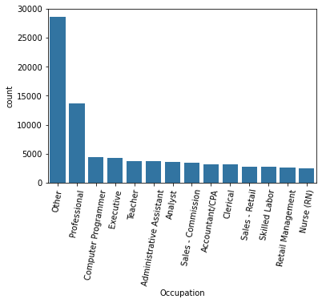

```python
THRESHOLD = 2000
base_color = sb.color_palette()[0]
occupation_frequency = loans['Occupation'].value_counts()
idx = np.sum(occupation_frequency > THRESHOLD)
most_occupation = occupation_frequency.index[:idx]
loans_sub = loans.loc[loans['Occupation'].isin(most_occupation)]
freq = loans_sub['Occupation'].value_counts()

occ_freq = freq.index
sb.countplot(data=loans_sub, x='Occupation', color= base_color, order=occ_freq     );
plt.xticks(rotation=80);
```

Excluding the occupation 'other'we have borrowers who are professionals being the most common occupation.

**Q6. What are some of the reasons for taking a loan and how do the reasons compare?**

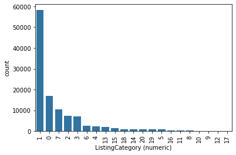

```python
freq = loans['ListingCategory (numeric)'].value_counts()

cat_freq = freq.index
sb.countplot(data=loans, x='ListingCategory (numeric)', color= base_color, order= cat_freq);

plt.xticks(rotation=90);
```

The three major reasons for taking (other than 0-not available and 7- other) loans are: 1-debt consolidation, 2-home improvement and 3-business.There are not much loans taken for 16-motorcycle, 11-engagement ring and 8-baby and adoption purposes. Loans are barely taken for 10- cosmetic procedure, 9-boat and 12-green loans

**Q7. What are the most number of borrowers prosper rating and score**

ProsperRating (Alpha) class is an ordinal variable with levels {AA,A,B,C,D,E,HR}.

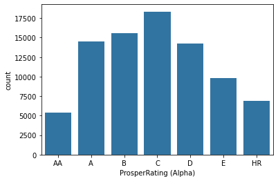

```python
# convert ProsperRating into ordered categorical types
credit_classes = ['AA', 'A', 'B', 'C', 'D','E','HR']

classes = pd.api.types.CategoricalDtype(ordered = True, categories = credit_classes)
loans['ProsperRating (Alpha)'] = loans['ProsperRating (Alpha)'].astype(classes)

sb.countplot(data=loans, x='ProsperRating (Alpha)', color= base_color);
```

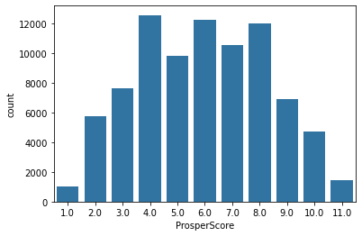

```python
sb.countplot(data=loans, x='ProsperScore', color= base_color);
```

The distribution is multimodial with peaks at 4, 6 and 8.

**Q8. What are the common Loanstatus among borrowers.**

**What other insights can we draw from the categorical variables "Term" and "IsBorrowerHomeowner"?**

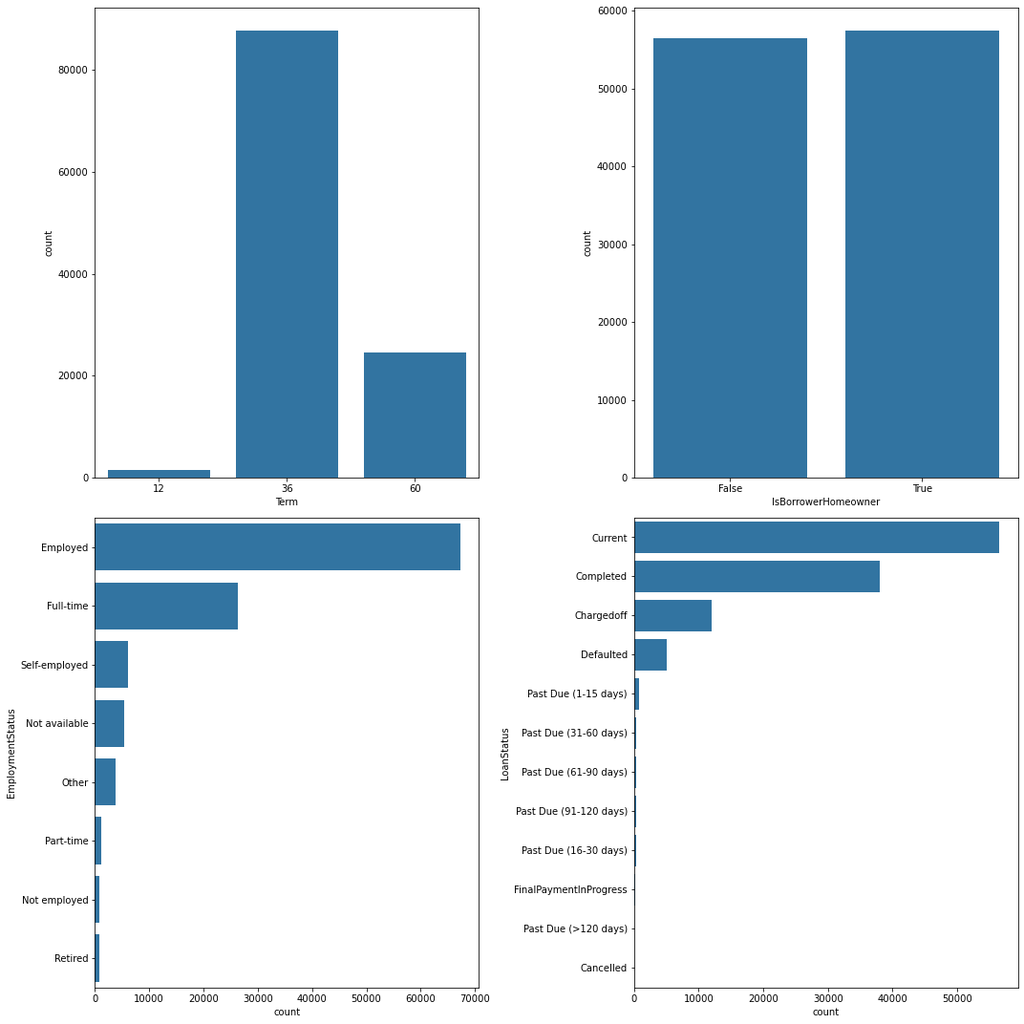

```python
fig, ax = plt.subplots(nrows=2,ncols=2, figsize = [15,15])

sb.countplot(data = loans, x = 'Term', color = base_color, ax = ax[0,0])

sb.countplot(data = loans, x = 'IsBorrowerHomeowner', color = base_color, ax = ax[0,1])

sb.countplot(data = loans, y = 'EmploymentStatus', order=loans.EmploymentStatus.value_counts().index, color = base_color, ax = ax[1,0])

sb.countplot(data = loans, y = 'LoanStatus', order=loans.LoanStatus.value_counts().index, color = base_color, ax = ax[1,1])

plt.tight_layout()
```

Most loans have a term of three years(36 months), followed by 5 years(60 months) then 1 year. There are more loan borrowers who are homeowners as compared to those who are not. Most loan borrowers are employed. Most people who are retired and not employed borrow less as compared to those who are not.

'LoanStatus' and 'EmploymentStatus' are nominal categorical data thus the order of the display of the bars can be computed with the following logic:

- Count the frequency of each unique value in the columns, and sort it in descending order
- Plot the bar chart in the decreasing order of the frequency of the 'Loanstatus'

### Discuss the distribution(s) of your variable(s) of interest. Were there any unusual points? Did you need to perform any transformations?

> Most loans have a term of three years(36 months), followed by 5 years(60 months) then 1 year.

> Most borrowers take a Loan for Debt Consolidation

### Of the features you investigated, were there any unusual distributions? Did you perform any operations on the data to tidy, adjust, or change the form of the data? If so, why did you do this?

> The distribution of the MonthlyLoanPayment had a long right tail. I performed a log transformation and the new plot had a big spike between 150 to 200 dollar.

> The distribution of monthlyiIncome is highly skewed to the right.To uncover a reason why I perforemed summary stattistics and noticed a very huge range between the maximum value and the third quartile value. My new plot contained only values below a certain threshold. Most of the monthly income for the borrowers is in range 2k to 6k.

## Bivariate Exploration

> In this section, investigate relationships between pairs of variables in your data. Make sure the variables that you cover here have been introduced in some fashion in the previous section (univariate exploration).

**Q9. What is the relationship between numerical variables?**

```python
#  first create a DataFrame with some the numerical variables then plot a correlation plot
numeric_vars = ['StatedMonthlyIncome','MonthlyLoanPayment','LoanOriginalAmount']
```

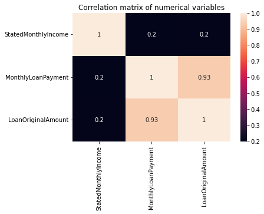

```python
df = loans[['StatedMonthlyIncome','MonthlyLoanPayment','LoanOriginalAmount']]
correlation_mat = df.corr()
sb.heatmap(correlation_mat, annot = True)
plt.title("Correlation matrix of numerical variables")
```

There is an approximately positive linear ralation between Monthly loan amount and Loan original amount and not a big corr between monthly income and monthly loan payment. We expect for a strong positive relationship between monthly loan payment and monthly income.It may be the case that the outliers present in monthly income may have brought down the correlation.

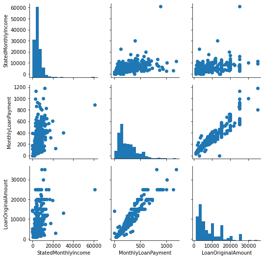

```python
# plot matrix: sample 500 loans so that plots are clearer and they render faster
samples = np.random.choice(loans.shape[0], 500, replace = False)
Loan_samp = loans.loc[samples,:]

g = sb.PairGrid(data = Loan_samp, vars = numeric_vars)
g = g.map_diag(plt.hist, bins = 20);
g.map_offdiag(plt.scatter);
```

There is an approximately positive linear ralation between Monthly loan payment and Loan original amount and not a big corr between monthly income and monthly loan payment. This is consistent with the findings from the correlation matrix plot above

**Q10. What is the relationship between categorical variables with numeric variables?**

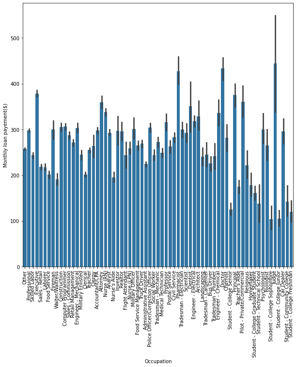

```python
plt.figure(figsize=[10,10])
sb.barplot(data=loans, x='Occupation', y='MonthlyLoanPayment', color=base_color)
plt.xticks(rotation=90);
plt.ylabel('Monthly loan payement($)')
```

the top 3 occupations in terms of monthly loan payment are judge, doctor and pharmacist. The groups that have lower monthly loan payment are students.

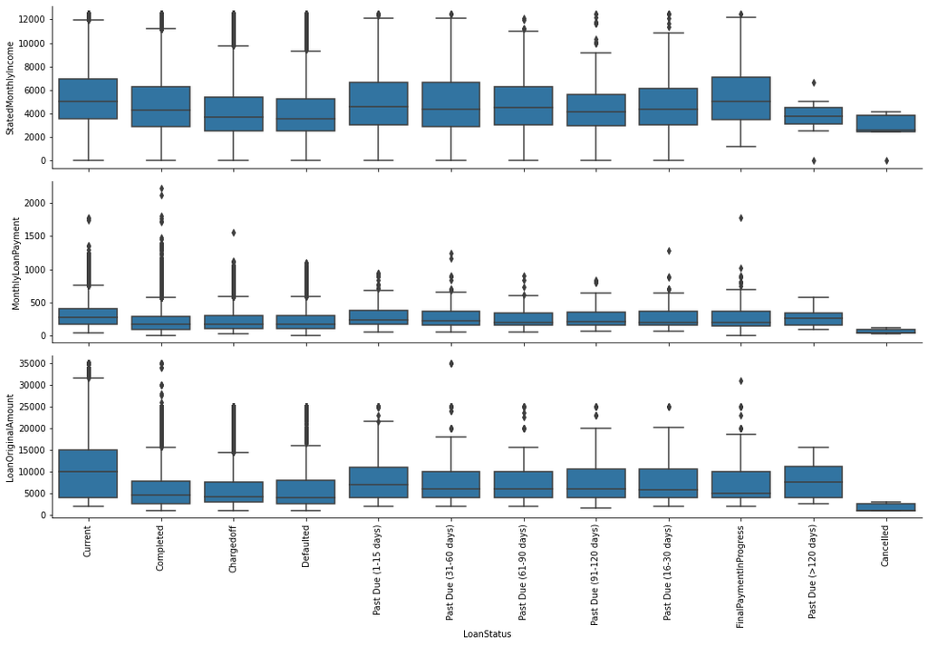

```python
#I have used the dataframe loans_1 which I created earlier. This df has monthly stated income not exceeding 12500
#since loanstatus is nominal it is important to order it according to frequencies of each categoty

def boxplots(x, y, **kwargs):
    default_color = sb.color_palette()[0]
    sb.boxplot(x, y, color = default_color, order=loans_1.LoanStatus.value_counts().index)
    plt.xticks(rotation=90)

plt.figure(figsize = [10, 10])
g = sb.PairGrid(data = loans_1, y_vars = numeric_vars, x_vars = 'LoanStatus',
                size = 3, aspect = 5)
g.map(boxplots)
plt.show();
```

Borrowers that passed their due date have a lower income but that is true from past due 1-15 days and borrowers that passed their due date > 120 days have a short distribution in monthly income.

There is a slight positive correlation between loan status and loan original amount in that: borrowers that pass their due date ask for a higher loan amount as compared to those who completed.

There is a negative correlation between monthly income and loan status in past due the lower the income, the more will be the delay in payment.

Borrowers who default have less loan original amount.

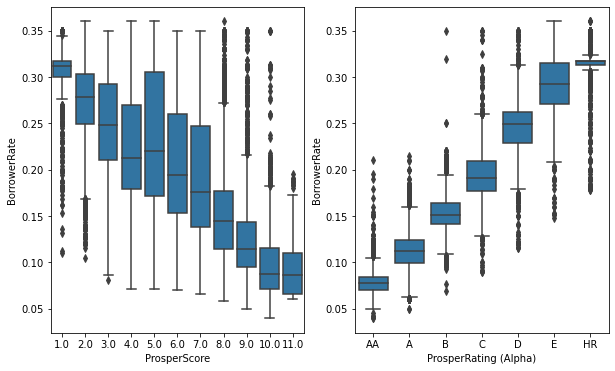

```python
plt.figure(figsize=[10,6])
plt.subplot(1, 2, 1)
ax1=sb.boxplot(data = loans, x = 'ProsperScore', y = 'BorrowerRate', color=base_color)

plt.subplot(1, 2, 2)
sb.boxplot(data = loans, x = 'ProsperRating (Alpha)', y = 'BorrowerRate', color=base_color)
```

The plot show strong correlation between the prosper rating and score with the borrower’s rate.As the score and rating improves, the interest rate shows a declining trend. This means that borrowers with better prosper score and rating are charged less interest for loans.

**Q11.What is the relationship between categorical variables?**

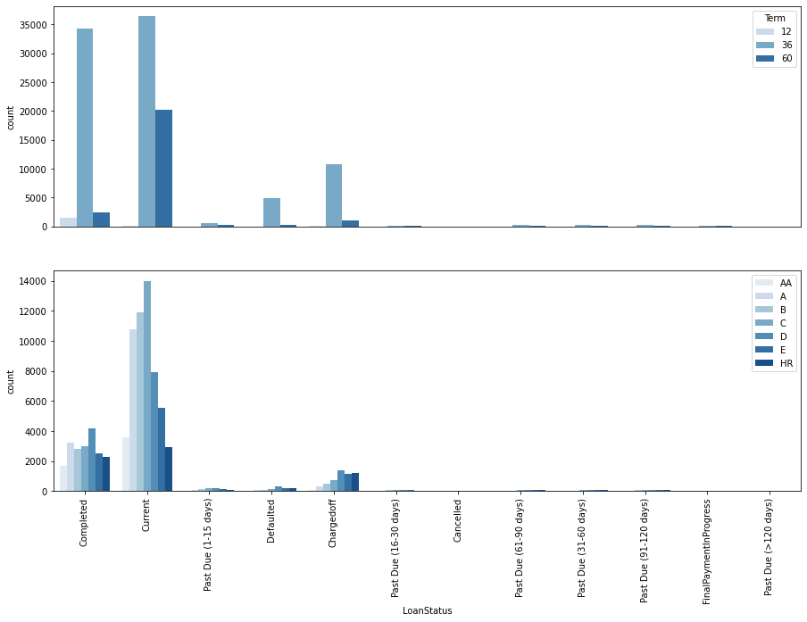

```python
fig , ax = plt.subplots(nrows=2,figsize= [15,10])

sb.countplot(data= loans,x='LoanStatus',hue='Term',palette="Blues",ax=ax[0])
ax[0].set_xticks([])
ax[0].set_xlabel('')
sb.countplot(data=loans,x='LoanStatus',hue='ProsperRating (Alpha)',palette="Blues",ax=ax[1])
plt.xticks(rotation = 90);
plt.legend(loc=1);
```

Borrowers who have completed their loan payment often borrow for 3 years and their credit score fall in most in A and D though they also have a relatively high number for credit scores E and HR. This may impliy that the credit score does not matter much. current borrowers borrow for 3 and 5 years term and almost none for 1 term.

Is risk management sytem at prosper efficient?

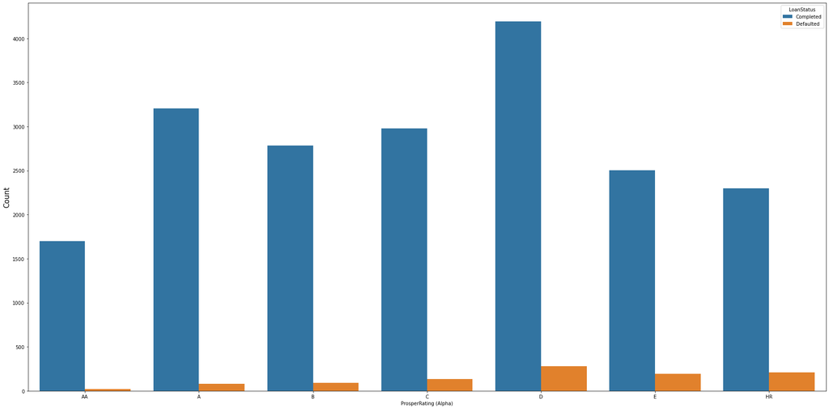

```python
loans_2 = pd.DataFrame(columns = ["LoanStatus","ProsperRating (Alpha)"])

loans_2["LoanStatus"] = loans[(loans['LoanStatus'] == 'Defaulted')| (loans['LoanStatus'] == 'Completed') ]['LoanStatus']
loans_2["ProsperRating (Alpha)"]=loans[(loans['LoanStatus'] == 'Defaulted') | (loans['LoanStatus'] == 'Completed') ]['ProsperRating (Alpha)']
plt.figure(figsize = (30,15))
ax2 = sb.countplot(hue="LoanStatus", x="ProsperRating (Alpha)" , data=loans_2)
ax2.set_ylabel("Count", fontsize = 15)
plt.show()
```

### Talk about some of the relationships you observed in this part of the investigation. How did the feature(s) of interest vary with other features in the dataset?

> There is a slight positive correlation between loan status and loan original amount in that: borrowers that pass their due data ask for a higher loan amount as compared to those who completed.

> There is a negative correlation between monthly income and loan status in past due the lower the income, the more will be the delay in payment.

### Did you observe any interesting relationships between the other features (not the main feature(s) of interest)?

> Borrowers who have completed their loan payment often borrow for 3 years and their credit score fall in most in A and D.

> current borrowers borrow for 3 and 5 years term and almost none for 1 term

## Multivariate Exploration

> Create plots of three or more variables to investigate your data even further. Make sure that your investigations are justified, and follow from your work in the previous sections.

**Q12. Has there been a consistent difference in borrower rate across the years for homeowner and non homeowners?**

```python
# changing the datatype for the 'ListingcreationDate' variable
loans['ListingCreationDate']= pd.to_datetime(loans['ListingCreationDate'])
```

```python
# creating a new column 'year' extracted from the column 'ListingCreationDate'
loans['year'] = loans['ListingCreationDate'].dt.year
```

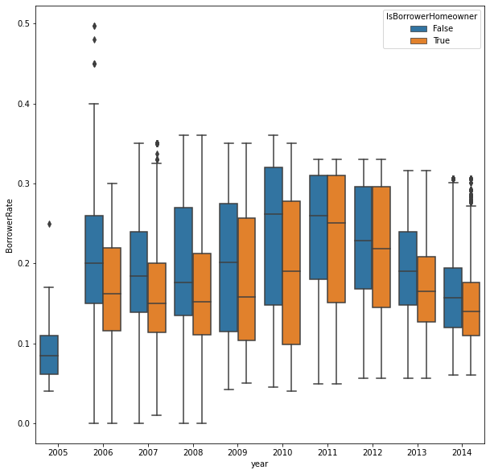

```python
plt.figure(figsize=[10,10])

sb.boxplot(data = loans, x = 'year', y = 'BorrowerRate', hue = 'IsBorrowerHomeowner')
```

This box plot shows relationships amoung three variables: borrower rate, time in years and whether the borrower is a homeowner or not.In general homeowners get a lower interest rate across the years as compared to those who are not homeowner.

**Q13. How does the three numerical variables 'StatedMonthlyIncome', 'MonthlyLoanPayment' and 'LoanOriginalAmount' relate with the categorical variables 'LoanStatus' and 'Term'?**

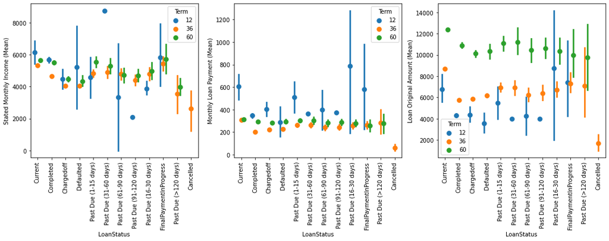

```python
fig, ax = plt.subplots(ncols = 3, figsize = [15,6])

sb.pointplot(data = loans_1, x = 'LoanStatus', y = 'StatedMonthlyIncome', hue = 'Term',order=loans.LoanStatus.value_counts().index,
              linestyles = '', dodge = 0.4, ax = ax[0])
ax[0].set_ylabel('Stated Monthly Income (Mean)')
ax[0].set_yticklabels([],minor = True)
ax[0].set_xticklabels(loans.LoanStatus.value_counts().index,rotation = 90)

sb.pointplot(data = loans_1, x = 'LoanStatus', y = 'MonthlyLoanPayment', hue = 'Term',order=loans.LoanStatus.value_counts().index,
              linestyles = '', dodge = 0.4, ax = ax[1])
ax[1].set_ylabel('Monthly Loan Payment (Mean)')
ax[1].set_yticklabels([],minor = True)
ax[1].set_xticklabels(loans.LoanStatus.value_counts().index,rotation = 90)
sb.pointplot(data = loans_1, x = 'LoanStatus', y = 'LoanOriginalAmount', hue = 'Term',order=loans.LoanStatus.value_counts().index,
              linestyles = '', dodge = 0.4, ax = ax[2])
ax[2].set_ylabel('Loan Original Amount (Mean)')
ax[2].set_yticklabels([],minor = True)
ax[2].set_xticklabels(loans.LoanStatus.value_counts().index,rotation = 90)

plt.tight_layout()
plt.show();
```

The delay in repayment often occurs when the monthly income is low

Most borrowers who need a loan of high amount make it for 5 Years

### Talk about some of the relationships you observed in this part of the investigation. Were there features that strengthened each other in terms of looking at your feature(s) of interest?

> The delay in loan repayment often occurs when the monthly income is low.

### Were there any interesting or surprising interactions between features?

> In general homeowners get a lower interest rate across the years as compared to those who are not homeowner.

> Most borrowers who need a loan of high amount make it for 5 Years

## Conclusions

> The major questions I wanted to answer with this data set are given below together with the findings
- **What factors affect a loan’s outcome status?**

Borrowers who have completed their loan payment often borrow for 3 years and their credit score fall in most in A and D.

There is a negative correlation between monthly income and loan status in past due the lower the income, the more will be the delay in payment.

There is a slight positive correlation between loan status and loan original amount in that: borrowers that pass their due date ask for a higher loan amount as compared to those who completed.

Borrowers who default have less loan original amount.

- **Are there differences between loans depending on how large the original loan amount was?**

Most borrowers who need a loan of high amount make it for 5 Years

Some borrowers ask for multiples of 5 or fractions of 5.

There is an approximately positive linear ralation between Monthly loan payment and Loan original amount. High monthly loan payments are made for loans that are high.

- **Does the prosper score and rate impact on borrowers rate?**

Borrowers with better prosper score and rating are charged less interest for loans.

- **Other relevant findings**

In general homeowners get a lower interest rate across the years as compared to those who are not homeowners.

The top 3 occupations in terms of monthly loan payment are judge, doctor and pharmacist. The groups that have lower monthly loan payment are students.

Most of the monthly income for the borrowers is in range 2k to 6k.

Most loans have a term of three years(36 months), followed by 5 years(60 months) then 1 year.

Most borrowers take a Loan for Debt Consolidation

## References

1.https://classroom.udacity.com/nanodegrees/nd002-alg-t2/parts/cd0016/modules/7e1817ca-5505-4583-b772-2e50d49a14a0/lessons/ls2240/concepts/f39200fa-cade-4584-9f43-09b694e7f5ef#

2.https://docs.google.com/spreadsheets/d/1gDyi_L4UvIrLTEC6Wri5nbaMmkGmLQBk-Yx3z0XDEtI/edit#gid=0

3.https://matplotlib.org/stable/plot_types/index.html

4.https://www.kaggle.com/code/muhamedhekal/prosper-loan-data-analysis#Bivariate-Exploration

5.https://www.kaggle.com/code/zeadomar/preliminary-eda-of-prosper-loan